# Community detection and randomizations

```r
library(igraph)
library(bipartite)
library(RColorBrewer)
```

# 1. Community detection (a.k.a “modularity”)

## 1.1 Unipartite networks

We will start with finding communities in **unipartite** networks. This is technically easier than in bipartite networks as the implementations are straightforward in `igraph`. From the help: “`igraph` implements a number of community detection methods (see them below), all of which return an object of the class `communities`. Because the community structure detection algorithms are different, `communities` objects do not always have the same structure.”

### Undirected, unweighted

Let’s try to detect communities in the Chesapeake Food Web from the last lab. This is a quantitative food web but for simplicity at this first stage we will work with an undirected, unweighted graph.

Load the web:

```r
chesapeake_nodes <- read.csv('https://raw.githubusercontent.com/pascualgroup/Networks_course/master/Network_data/Chesapeake_bay_nodes.csv?token=ADd8OB99ouaZ72g32T037z_fAk33r_R_ks5a1IuYwA%3D%3D', header=F)
names(chesapeake_nodes) <- c('nodeId','species_name')
chesapeake_links <- read.csv('https://raw.githubusercontent.com/pascualgroup/Networks_course/master/Network_data/Chesapeake_bay_links.csv?token=ADd8OMagGAfcXWC6rTyJV7gCv4OfclgXks5a1IurwA%3D%3D', header=F)
names(chesapeake_links) <- c('from','to','weight')
ches_web <- graph.data.frame(chesapeake_links, vertices = chesapeake_nodes, directed = T)
```

Detect communities, note the `as.undirected` command:

```r
ches_web_unweighted <- ches_web
ches_web_unweighted <- as.undirected(ches_web_unweighted)
E(ches_web_unweighted)$weight <- 1
cl <- cluster_louvain(ches_web_unweighted) # Can also use the weights = NULL argument
class(cl) # the result is of class communities
```

```
## [1] "communities"
```

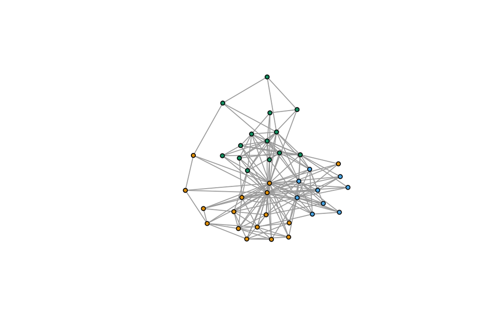

```r
module_membership <- membership(cl)
cols <- data.frame(mem=unique(module_membership), col= brewer.pal(length(unique(module_membership)), 'Set1'))
V(ches_web_unweighted)$module_membership <- module_membership
V(ches_web_unweighted)$color <- cols$col[match(V(ches_web_unweighted)$module_membership, cols$mem)]
plot(ches_web_unweighted, vertex.color=V(ches_web_unweighted)$color, vertex.size=5, vertex.label=NA, edge.arrow.width=0.3, edge.arrow.curve=0.5)
```

### Undirected, weighted

We will use the same data set to see if there are any differences in the results.

```r
cl_wt <- cluster_louvain(as.undirected(ches_web), weights = E(ches_web)$weight) #Notice the `weights` argument.
class(cl_wt) # the result is of class communities
```

```
## [1] "communities"
```

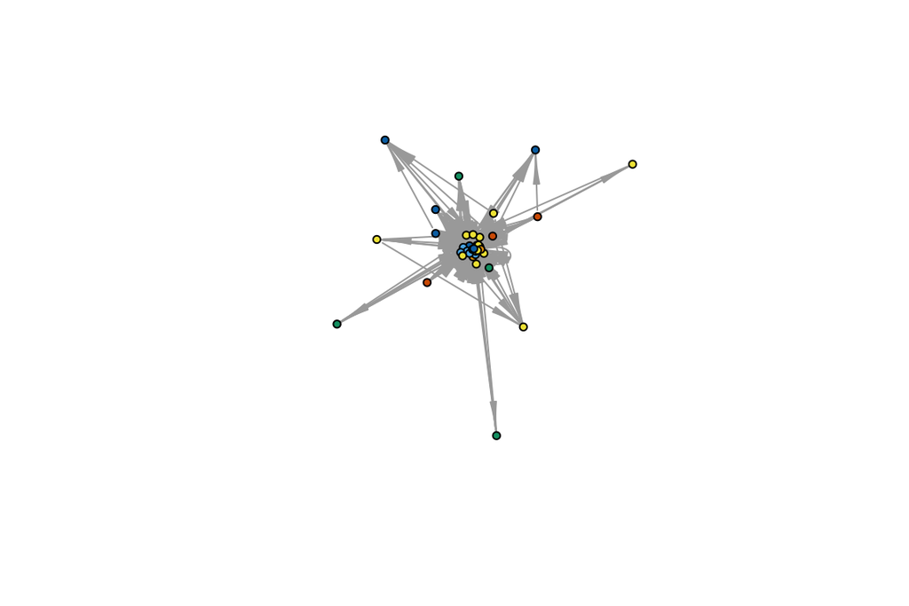

```r
module_membership_wt <- membership(cl_wt)
cols <- data.frame(mem=unique(module_membership_wt), col= brewer.pal(length(unique(module_membership_wt)), 'Set1'))
V(ches_web)$module_membership_wt <- module_membership_wt
V(ches_web)$color_wt <- cols$col[match(V(ches_web)$module_membership_wt, cols$mem)]
plot(ches_web, vertex.color=V(ches_web)$color_wt, vertex.size=5, vertex.label=NA, edge.arrow.width=0.3, edge.arrow.curve=0.5)
```

> 4. Are the module assignments the same as in the unweighted network?

### Directed networks

We will not touch upon directed networks in the context of modularity maximization, although there is a development for it by Guimera et al (2007). The description of the sofware and the associated papers is [here](http://seeslab.info/downloads/bipartite-modularity/). The problem is that it is not available in an easy package, so you will have to hack your way through this. In fact, for directed networks I recommend using Infomap. In `R` this can be achieved with igraph’s `cluster_infomap`.

# 2. Infomap

Modularity maximization is only one way to detect communities. While modularity is based on a null model, other methods, such as the Map Equation (Rosvall et al., 2010), are based on flow. All the information you need on the Map Equation and its implementation in Infomap are [here])(http://www.mapequation.org/). Infomap is the most flexible method available: it can handle unipartite, bipartite, and multilayer networks, weighted and directed.

# 3. Bipartite networks

The difference between bipartite and unipartite networks lies in the “null” term of the modularity function, which should account for the fact that edges cannot be expected between nodes of the same set. This is well expalined in (Guimera et al. 2007; Barber 2007) and reviewed in the context of ecology by Thebault (2013). Each of these have their own software associated with their papers. But for the sake of this exercise we are looking for an implementation to optimize modularity maximization which will be readily available, and also will allow us to analyze batches of networks (for testing patterns against shuffled networks). The `bipartite` package has a recent implementation of Stephen Beckett’s **DIRTLPAwb+** algorithm (Beckett 2016). This algorithm maximizes a modularity function for weighted bipartite networks (Dorman & Strauss 2014), which is a recent extention of Barber’s (2007) method and is reduced to it if the input is a binary network. All this can be a bit confusing so it is strongly suggested to read these papers if you are about to apply these methods for community detection in your research.

```r
mod <- computeModules(memmott1999)
slotNames(mod) # see ?moduleWeb for details
```

```
## [1] "originalWeb" "moduleWeb"   "orderA"      "orderB"      "modules"
## [6] "likelihood"
```

```r
mod@likelihood # This is the value of the modularity function Q. NOTICE THE @ SIGN (instead of $).
```

```
## [1] 0.3044216
```

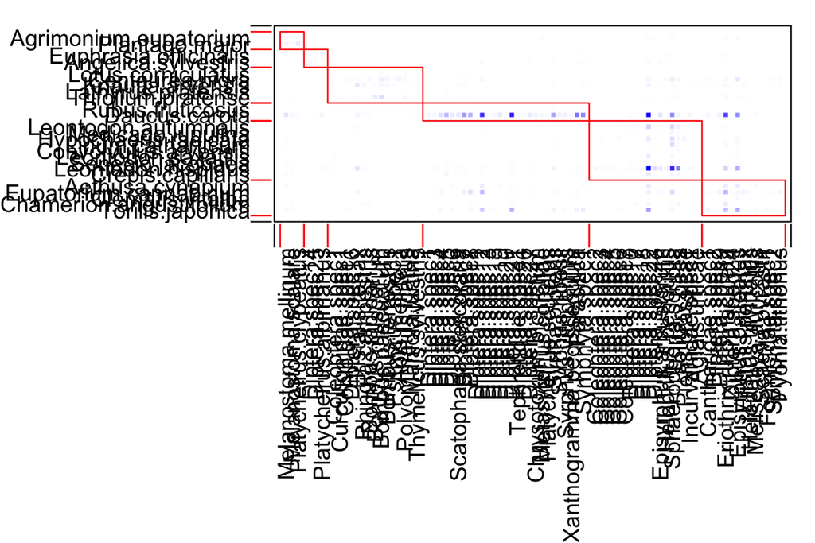

```r
module_list <- listModuleInformation(mod) # The output is rather cumbersome...
plotModuleWeb(mod)
```

```r
module_list <- module_list[[2]] # let's look at the modules. The first element in the list is the whole network, so start with 2
for (i in 1:2){ # Show the two first modules.
  message(paste('Module:',i))
  print(module_list[[i]])
}
```

```
## Module: 1
```

```
## [[1]]
## [1] "Agrimonium.eupatorium" "Plantago.major"
##
## [[2]]
## [1] "Melanostoma.mellinum"   "Melanostoma.scalare"
## [3] "Platycheirus.clypeatus"
```

```
## Module: 2
```

```
## [[1]]
## [1] "Euphrasia.officinalis" "Angelica.sylvestris"
##
## [[2]]
## [1] "Diptera.spec14"         "Diptera.spec25"
## [3] "Platycheirus.albimanus"
```

This list data structure is horrible for analysis. THis code transforms it to a data frame:

```r
# Transform the lists to data frames
m <- length(module_list) # Number of modules
mod_plants <- unlist(module_list, recursive = F)[seq(1,2*m,2)] # Assignments of plants
names(mod_plants) <- 1:m
mod_pollinators <- unlist(module_list, recursive = F)[seq(2,2*m,2)] # Assignments of pollinators
names(mod_pollinators) <- 1:m
tmp_plants <- data.frame(module = rep(names(mod_plants), sapply(mod_plants, length)), species = unlist(mod_plants), type='Plants')
tmp_poillnators <- data.frame(module = rep(names(mod_pollinators), sapply(mod_pollinators, length)), species = unlist(mod_pollinators), type='Pollinators')
# Make one data frame
module_assignments <- rbind(tmp_plants,tmp_poillnators)
```

> 5. Try to calculate modularity for the binary version of this web. How do the results differ?
> 6. Can you project the network and calculate modularity in each of the projections? Do plants that cluster together in the projection also cluster together in the bipartite version? Is there an difference in the ecological interpretation between these two scenarios?

# 4. Randomizations

We are going to focus on the randomizations of **binary bipartite** networks, although of course it is posible to randomize unipartite networks (adjacency matrices) and weighted uni/bipartite networks. Randomizations do not generate new data per se, but rather create some randomness through shuffling, in already existing data. The literature on matrix randomizations in Ecology is vast and a few good places to start are specified below in references.

As a general guideline, two things should be considered when selecting a randomization procedure: 1. **What is the null hypothesis?** For example, randomizing a plant-pollinator matrix while maintaining only the density assumes that pollinators have no dietary restritions and that plants have not evolved to be specialized for specific pollinators. In other words, that the niche breadth of each species is unlimited in this system. This is obviously a very permissive model. 2. **How sensitive is the model** to type-I/II errors, as well as some other limitations such as consistency of results and computation time.

In this lab we will introduce a few algorithms for the sake of introduction. Broadly speaking, in the network ecology literature null models are:

1. **equiprobable**: assign the same probability to each potential interaction in the network.
2. **probabilistic**: assign a probability to each potential interaction proportional to the number of observed interactions between partners.
3. **fixed**: randomly shuffle the interactions while preserving the observed number of partners of each species.

In `R`, these three kind of shuffling algorithms are available within `vegan`. Let’s see them:

```r
library(vegan)
?commsim
```

Now let’s shuffle a matrix:

```r
num_iterations <- 10
memmott1999_binary <- memmott1999
memmott1999_binary[memmott1999_binary>0] <- 1
null_model <- vegan::nullmodel(memmott1999_binary, method = 'r00')
shuffled_r00 <- simulate(null_model, nsim = num_iterations)
apply(shuffled_r00, 3, dim) # This produces an array with 10 matrices, each of them is a shuffled matrix.
```

```
##      sim_1 sim_2 sim_3 sim_4 sim_5 sim_6 sim_7 sim_8 sim_9 sim_10
## [1,]    25    25    25    25    25    25    25    25    25     25
## [2,]    79    79    79    79    79    79    79    79    79     79
```

```r
# Calculate the density of each of these matrices:
connectance <- function(m){
  d <- sum(m>0)/(nrow(m)*ncol(m))
  return(d)
}
apply(shuffled_r00, MARGIN = 3, connectance)
```

```
##     sim_1     sim_2     sim_3     sim_4     sim_5     sim_6     sim_7
## 0.1513924 0.1513924 0.1513924 0.1513924 0.1513924 0.1513924 0.1513924
##     sim_8     sim_9    sim_10
## 0.1513924 0.1513924 0.1513924
```

> 7. What kind of model (equiprobable, probabilistic, fixed) is `r00`?
> 8. Can you program the algorithm for `r00` by yourself?

`r00` does not preserve row or column marginal sums. A more conservative null hypothesis is to conserve either, or both (‘fixed’ null model). Algorithms that consere both are commonly based on randomly selcting 2x2 sub-matrices and then swap their cell entries (“swap” algorithms). However, swap algorithms suffer from several disadvantages in computation time and sampling limitations of the “null space” (discussed in the referecnces below). A new algoritm that overcomes those limitations is the **curveball** algorithm (Strona et al. 2014). Note that this is a *sequential algorithm* in which matrices are genrated based on previous ones so for accuray the first generated matrices should be discarded. This is done using the `burnin` argument.

```r
num_iterations <- 10
null_model_curveball <- vegan::nullmodel(memmott1999_binary, method = 'curveball') # Only preserve matrix fill (density)
shuffled_curveball <- simulate(null_model_curveball, nsim = num_iterations, burnin = 1000)
apply(shuffled_curveball, MARGIN = 3, connectance) # Calculate the density of each of these matrices
```

```
##     sim_1     sim_2     sim_3     sim_4     sim_5     sim_6     sim_7
## 0.1513924 0.1513924 0.1513924 0.1513924 0.1513924 0.1513924 0.1513924
##     sim_8     sim_9    sim_10
## 0.1513924 0.1513924 0.1513924
```

```r
# Did the algorithm match the row  and column sums?
all(apply(shuffled_curveball, MARGIN = 3, rowSums)==rowSums(memmott1999_binary))
```

```
## [1] TRUE
```

```r
all(apply(shuffled_curveball, MARGIN = 3, colSums)==colSums(memmott1999_binary))
```

```
## [1] TRUE
```

```r
# Did it shuffle any interactions?
for (i in 1:num_iterations){
  if(!identical(shuffled_curveball[,,i], memmott1999_binary)){
    print(paste('Shuffled matrix',i,'is different than the original'))
  }
}
```

```
## [1] "Shuffled matrix 1 is different than the original"
## [1] "Shuffled matrix 2 is different than the original"
## [1] "Shuffled matrix 3 is different than the original"
## [1] "Shuffled matrix 4 is different than the original"
## [1] "Shuffled matrix 5 is different than the original"
## [1] "Shuffled matrix 6 is different than the original"
## [1] "Shuffled matrix 7 is different than the original"
## [1] "Shuffled matrix 8 is different than the original"
## [1] "Shuffled matrix 9 is different than the original"
## [1] "Shuffled matrix 10 is different than the original"
```

Using these randomizations, let’s test if the binary version of the `memmot1999` data is “significantly” compartmentalized. Here we only present the code, without evaluating it because it takes alot of time…

```r
web <- memmott1999_binary
web[web>0] <- 1
mod_observed <- computeModules(web)
Q_obs <- mod_observed@likelihood # This is the value of the modularity function Q

# Now shuffle
num_iterations <- 100
null_model <- vegan::nullmodel(web, method = 'r00') # Only preserve matrix fill (density)
shuffled_r00 <- simulate(null_model, nsim = num_iterations)
# Calculate modularity of the shuffled networks
Q_shuff <- NULL
for (i in 1:100){
  mod <- computeModules(shuffled_r00[,,i])
  Q_shuff <- c(Q_shuff, mod@likelihood)
}
#Which proportion of the simulations have a Q value larger than the observed?
P_value <- sum(Q_obs < Q_shuff)/length(Q_shuff)
```

> 9. Pick another data set from the biparite package and test if it is significantly modular compared to two null models. Don’t forget to transform it to its binary version! (Or, alternatively, use null models for quantitative networks).
> 10. There is no better way to understand the mechanics of randomization algorithms than to program one for yourself! Try to program the probailistic model from [6]: “The probability of each cell being occupied is the average of the probabilities of occupancy of its row and column.” This means that the probability of drawing an interaction is proportional to the degree of both the lower-level and the higher-level species. Mathematically: $P_{ij}=\left(\frac{\sum A_{i}}{j}+\frac{\sum A_{j}}{i}\right)/2$, where $A_{ij}$ is the incidence matrix in which $i$ and $j$ denote species in the rows and columns, respectively. Try to program that algorithm. Can you note one problem that occurs with the output?

# 5. References

## 5.1 Community detection:

- Barber M. Modularity and community detection in bipartite networks. Physical Review E. 2007;76: 1–9.
- Beckett SJ. Improved community detection in weighted bipartite networks. R Soc Open Sci. 2016;3: 140536.
- Dormann CF, Strauss R. A method for detecting modules in quantitative bipartite networks. Methods Ecol Evol. 2014;5: 90–98.
- Guimerà R, Sales-Pardo M, Amaral LAN. Module identification in bipartite and directed networks. Phys Rev E Stat Nonlin Soft Matter Phys. 2007;76: 036102.
- Rosvall M, Axelsson D, Bergstrom CT. The map equation. Eur Phys J Spec Top. Springer-Verlag; 2010;178: 13–23.
- Thébault E. Identifying compartments in presence-absence matrices and bipartite networks: insights into modularity measures. J Biogeogr. 2013;40: 759–768.)

## 5.2 Randomizations

- Bascompte J, Jordano P, Melián CJ, Olesen JM. The nested assembly of plant–animal mutualistic networks. Proc Natl Acad Sci U S A. 2003;100: 9383–9387.
- Gotelli NJ. Null Model Analysis of Species Co-Occurrence Patterns. Ecology. Ecological Society of America; 2000;81: 2606–2621.
- Hardy OJ. Testing the spatial phylogenetic structure of local communities: statistical performances of different null models and test statistics on a locally neutral community. J Ecol. Blackwell Publishing Ltd; 2008;96: 914–926.
- Strona G, Nappo D, Boccacci F, Fattorini S, San-Miguel-Ayanz J. A fast and unbiased procedure to randomize ecological binary matrices with fixed row and column totals. Nat Commun. 2014;5: 4114.
- Ulrich W, Gotelli NJ. Null model analysis of species associations using abundance data. Ecology. 2010;91: 3384–3397.
- Ulrich W, Gotelli NJ. Null model analysis of species nestedness patterns. Ecology. Wiley Online Library; 2007;88: 1824–1831.